# Task 2

### 3. Plotting in Base R

R has excellent built-in graphics capabilities. It is useful to observe values, potential trends, and relationships between variables. Here are some key plotting functions from base R:

- `plot()` - Scatterplot
- `hist()` - Histogram
- `barplot()` - Bar chart
- `boxplot()` - Boxplot
- `pie()` - Pie chart

You can build almost any type of plot using `plot()` by specifying additional arguments. Plot types like scatterplots, histograms and boxplots are useful for initial visual exploration of data. Bar and pie charts can visualize categorical data.

Here is an example with the `mtcars` dataset:

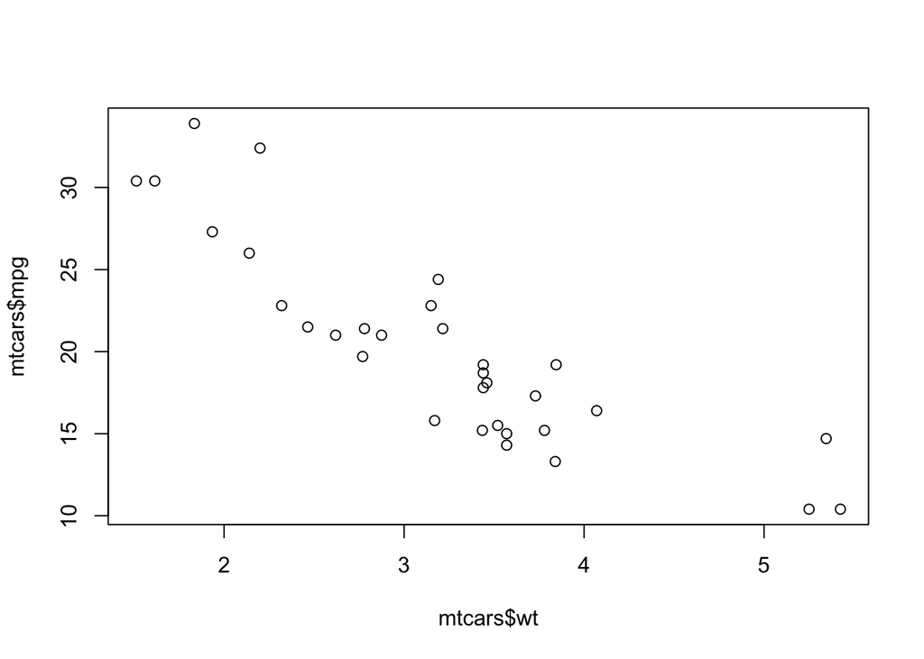

```r
# Scatterplot
plot(mtcars$wt, mtcars$mpg)
```

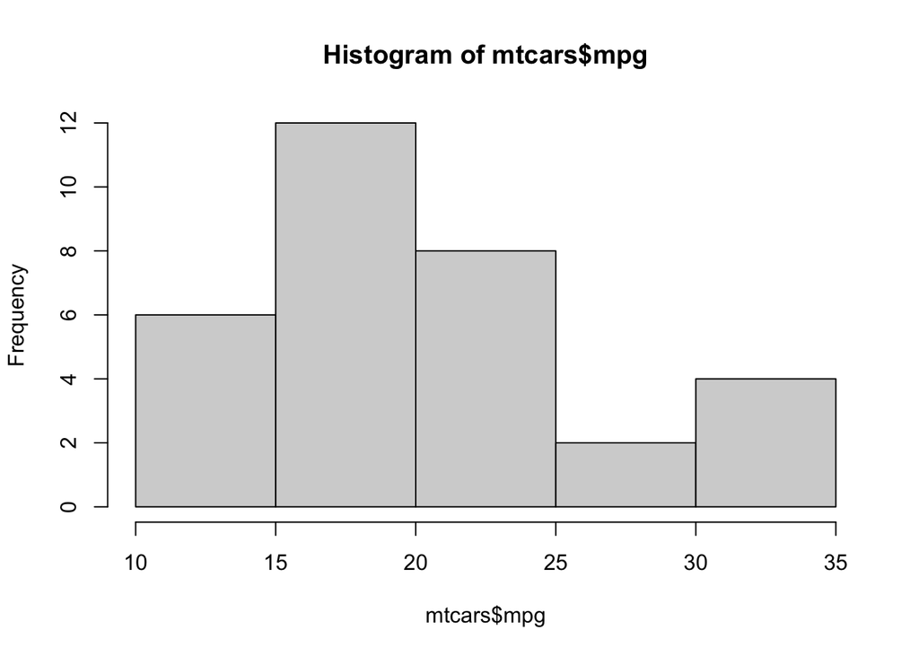

```r
# Histogram
hist(mtcars$mpg)
```

We’ll explore plotting in greater detail later in the course and introduce another R packages for better visualization.

Rememver, the first step of any analysis is to understand the data type, data structure, consider summary statistics, and create basic visualizations.

#### **Your Task**

Complete the following tasks related to the content of this week.

#### 1. The National Parks

Write a script in R that performs the following tasks:

1. Create a new DataFrame that includes information about 15 (or more) National Parks of your choice *(e.g. Bryce Canyon, Everglades, Olympic, etc.).* Add a column for the “name”, one for date “established”, another for “state”, one for “area” of the park, and a field indicating the number of “visitors” in 2022. *You can find this information [here](https://en.wikipedia.org/wiki/List_of_national_parks_of_the_United_States). Advanced students should try to scrape the table of National Parks in the link above and respond to these questions using the full dataset*
2. What is the average size of the National Parks in your DataFrame? What is the total area of all National Parks?
3. Which National Parks in your list had the greatest and least visitation in 2022? What is the total number of visitors for all National Parks in 2022?
4. What is the difference in years between the earliest established park and the latest park in your DataFrame? What is the difference in area between these two parks?
5. Create a plot showing the date established vs. size from your data of National Parks. Create another plot showing park size vs visitation. Are there any potential relationships between these variables in the national parks.
6. Describe your dataset using several functions listed above. Brainstorm a few other useful ways that you could either analyze or organize this dataset.

#### 2. The Iris Dataset

In the second part of your task this week, you will describe an existing dataset and recreate a plot. Your plot will use base functions in R, which is to say that you do not need any additional packages *We’ll use several great R libraries throughout the semester.*

**For this task** you will recreate the following graph:

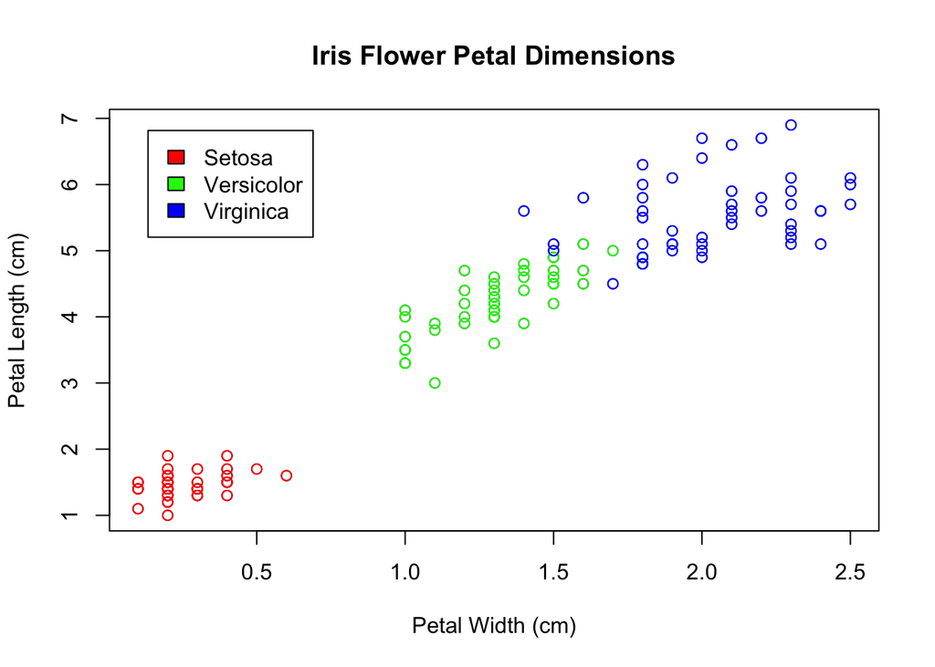

This code uses the famous `iris` dataset (Fisher and Anderson), which gives the measurements in centimeters of the variables sepal length and width and petal length and width, respectively, for 50 flowers from each of 3 species of iris. You should be able to directly call the `iris` dataset in R at any time, if not, use `data(iris)` to load the DataFrame into memory

7.) *(2 points)* Describe the iris dataset using the various functions we’ve discussed. Include information about the dimentions, data types, and data structure. Summary statistics can also be useful.

8.) *(2 points)* Recreate the plot above. Describe any relationships you find and suggest additional steps that you could take to better understand any relationship between variables.

*For each step, annotate your code. In other words, add a `#` to comment on the functions you are using and describe the code you write.*

#### Submitting

Upload a R script with responses to each question. Support your responses with stand-alone code. Comment out any text.

*Please reach out if you have any questions or concerns!*

**This assignment is due in one week but may be turned for an additional week with a late penalty of -5%**